## 流程

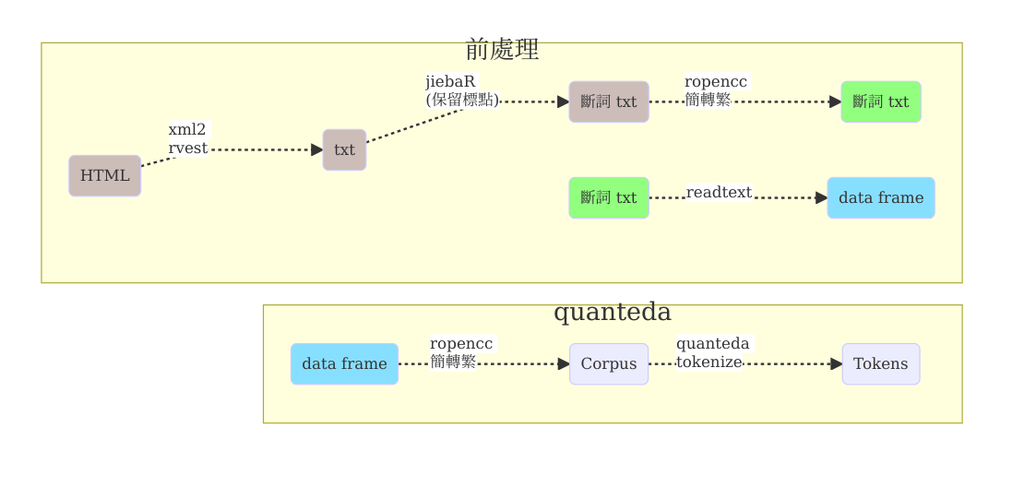

## 爬資料

這邊使用金庸神雕俠侶第二至第八回的文本當作分析資料。 在下面的網站，小說的每一回是一個獨立的`htm`檔。 如果使用 Mac 或是 Linux 系統，可直接透過`bash`指令下載網頁：

```bash
cd ~/quanteda-chinese/htm
url=http://www.millionbook.net/wx/j/jingyong/sdxl/
wget ${url}{002..008}.htm
```

## `rvest`: 清理 HTML

下載網頁後，需將網頁不必要的資訊去除，只留下文本資料。這裡透過 R 的[`rvest`](https://github.com/hadley/rvest)套件處理。

### 剖析 HTML 結構

清理 HTML 的第一步並非打開 R，而是打開瀏覽器的開發者工具(按`Ctrl + Shift + I`)，按下右欄左上角的選擇符號(見下圖)，接著就能在瀏覽器上選擇網頁的區塊

[figure not shown]

選擇左邊的區塊後，右欄的開發者工具列會自動標示對應的 HTML 元素(如圖，`<td class="tt2" ...`這行自動反白)。此時，便可在反白的那個元素上按`右鍵`>`Copy`>`(CSS) Selector`，將複製下來的文字保存(在此應為`.tt2`)。

### 擷取 HTML 元素內容

有了 CSS Selector 之後，擷取文字內容變得非常容易，僅需 3 個函數：`read_html()`, `html_nodes()`, `html_text()`

```r
library(rvest)
text <- read_html("htm/002.htm") %>%
    html_nodes(".tt2") %>% html_text()

strtrim(text, 300) # String too long, display a portion
```

```
[1] "第二回　故人之子\r\n\r\n　　武三娘正沒做理會處，忽聽得丈夫叫喚，又喜又惱，心想你這瘋子不知在胡鬧些什麼，卻到這時才來，只見他上身扯得破破爛爛，頸中兀自掛著何沅君兒時所用的那塊圍涎，急奔而至，不住的叫道：「娘子，你沒事麼？」她近十年來從未見丈夫對自己這般關懷，心中甚喜，叫道：「我在這裡。」武三通撲到跟前，"
```

接著需將擷取下來的`text`儲存成`.txt`檔

```r
readr::write_file("txt/002.txt")
```

因為要重複處理第二至第八回，我們可以將上面的程式碼改寫成`for`迴圈的形式：

```r
library(readr)
for (i in paste0(0, 2:8)) {
        path1 <- paste0("htm/0",i,".htm")
        path2 <- paste0("txt/original/0",i,".txt")
    read_html(path1) %>%
        html_nodes(".tt2") %>% html_text() %>%
        write_file(path2)
}
```

`txt/original/`資料夾：

```
## 002.txt
## 003.txt
## 004.txt
## 005.txt
## 006.txt
## 007.txt
## 008.txt
```